# Doing Data Science (EDA - Chapter2)

Bijan Ranjbar-Sahraei

Exploratary Data Analysis of sample datasets.

# Initialization

First let’s clean up memory

```r
rm(list=ls())
```

This is the Address to data folder

```r
data_folder <- "/Users/bian/sandbox/doing_data_science-master/dds_datasets/dds_ch2_nyt/"
```

## Let’s play around a bit

reading the csv file

```r
data1 <- read.csv(paste(data_folder, "nyt1.csv", sep=''))
```

To see how data looks like at the begining and at the end

```r
head(data1)
```

```
##   Age Gender Impressions Clicks Signed_In
## 1  36      0           3      0         1
## 2  73      1           3      0         1
## 3  30      0           3      0         1
## 4  49      1           3      0         1
## 5  47      1          11      0         1
## 6  47      0          11      1         1
```

```r
tail(data1)
```

```
##        Age Gender Impressions Clicks Signed_In
## 458436  51      0           7      0         1
## 458437   0      0           2      0         0
## 458438   0      0           4      0         0
## 458439  72      1           5      0         1
## 458440   0      0           5      0         0
## 458441   0      0           3      0         0
```

To get the column names

```r
colnames(data1)
```

```
## [1] "Age"         "Gender"      "Impressions" "Clicks"      "Signed_In"
```

To get a summary

```r
summary(data1)
```

```
##       Age             Gender       Impressions         Clicks
##  Min.   :  0.00   Min.   :0.000   Min.   : 0.000   Min.   :0.00000
##  1st Qu.:  0.00   1st Qu.:0.000   1st Qu.: 3.000   1st Qu.:0.00000
##  Median : 31.00   Median :0.000   Median : 5.000   Median :0.00000
##  Mean   : 29.48   Mean   :0.367   Mean   : 5.007   Mean   :0.09259
##  3rd Qu.: 48.00   3rd Qu.:1.000   3rd Qu.: 6.000   3rd Qu.:0.00000
##  Max.   :108.00   Max.   :1.000   Max.   :20.000   Max.   :4.00000
##    Signed_In
##  Min.   :0.0000
##  1st Qu.:0.0000
##  Median :1.0000
##  Mean   :0.7009
##  3rd Qu.:1.0000
##  Max.   :1.0000
```

get a specific columns

```r
head(data1$Age)
```

```
## [1] 36 73 30 49 47 47
```

# Ex1.

Add a new variable age_group that categorizes users between differen age groups

```r
data1$age_group <- cut(data1$Age, c(-Inf, 0, 18, 24, 34, 44, 54, 65, Inf))
head(data1)
```

```
##   Age Gender Impressions Clicks Signed_In age_group
## 1  36      0           3      0         1   (34,44]
## 2  73      1           3      0         1 (65, Inf]
## 3  30      0           3      0         1   (24,34]
## 4  49      1           3      0         1   (44,54]
## 5  47      1          11      0         1   (44,54]
## 6  47      0          11      1         1   (44,54]
```

Just to check subset of data which doesn’t have any age

```r
head(subset(data1, age_group == "(-Inf,0]"))  # it seems that these guys are not sign in, that's why!
```

```
##    Age Gender Impressions Clicks Signed_In age_group
## 7    0      0           7      1         0  (-Inf,0]
## 11   0      0           8      1         0  (-Inf,0]
## 13   0      0           4      0         0  (-Inf,0]
## 16   0      0           6      0         0  (-Inf,0]
## 20   0      0           5      0         0  (-Inf,0]
## 25   0      0           4      0         0  (-Inf,0]
```

## doBy

Let’s use the “doBy”" package To do something on data stratified ‘by’ some other variables. here we use the summaryBy function

```r
# install.packages("doBy")
library("doBy")
siterange <- function(x) {c(length(x), min(x), mean(x), max(x)) }
siterange(data1$Age)
```

```
## [1] 458441.00000      0.00000     29.48255    108.00000
```

```r
summaryBy(Age~age_group, data = data1, FUN=siterange)  # summariszing Age based on age-group
```

```
##   age_group Age.FUN1 Age.FUN2 Age.FUN3 Age.FUN4
## 1  (-Inf,0]   137106        0  0.00000        0
## 2    (0,18]    19252        7 16.03350       18
## 3   (18,24]    35270       19 21.26904       24
## 4   (24,34]    58174       25 29.50335       34
## 5   (34,44]    70860       35 39.49468       44
## 6   (44,54]    64288       45 49.49258       54
## 7   (54,65]    45805       55 59.62635       65
## 8 (65, Inf]    27686       66 73.29658      108
```

Let’s see a summary of everything for each age category

```r
summaryBy(Gender+Signed_In+Impressions+Clicks~age_group, data=data1)
```

```
##   age_group Gender.mean Signed_In.mean Impressions.mean Clicks.mean
## 1  (-Inf,0]   0.0000000              0         4.999657  0.14207985
## 2    (0,18]   0.6421151              1         4.998961  0.13105132
## 3   (18,24]   0.5338531              1         5.006635  0.04845478
## 4   (24,34]   0.5321621              1         4.993829  0.05048647
## 5   (34,44]   0.5316963              1         5.021507  0.05167937
## 6   (44,54]   0.5289790              1         5.010406  0.05027377
## 7   (54,65]   0.5362952              1         5.023207  0.10263072
## 8 (65, Inf]   0.3564256              1         5.010475  0.15188182
```

*It seems that the just those who haven’t signed in has a zero age.*

# Ex2.a

Plot the distribution of number impressions and click through-rate for the age categories

## Plotting Impressions based on age category

let’s plot a bit

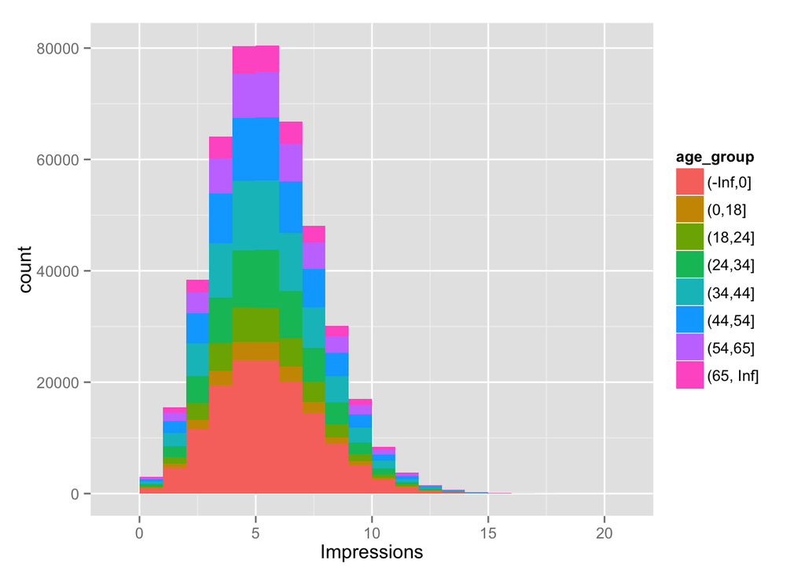

```r
# install.packages("ggplot2")
library(ggplot2)
ggplot(data1, aes(x=Impressions, fill=age_group)) + geom_histogram(binwidth=1)  # woohoo!!
```

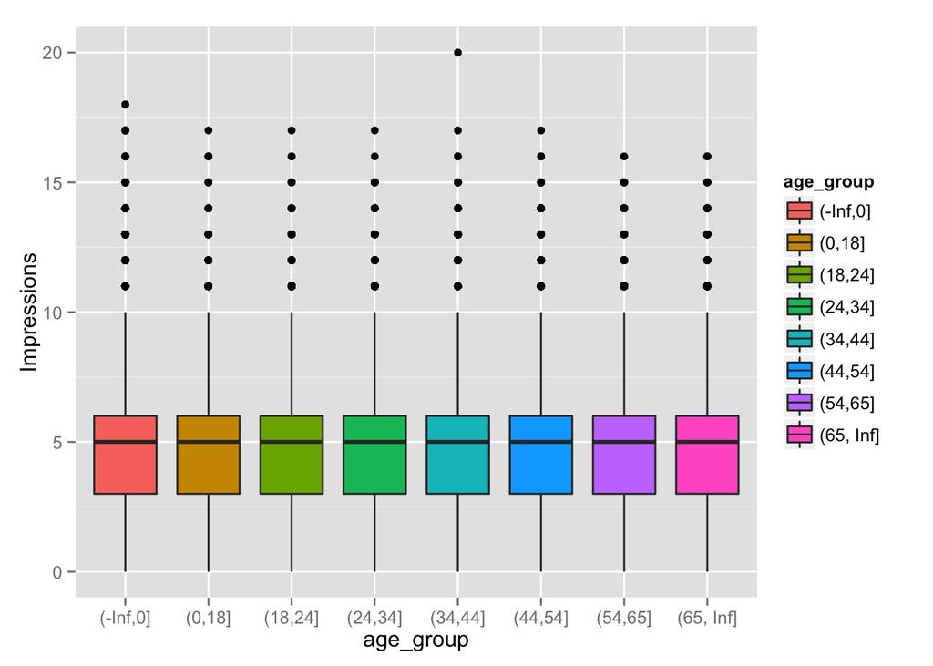

```r
ggplot(data1, aes(x=age_group, y=Impressions, fill=age_group)) + geom_boxplot()
```

Let’s check data with no impression

```r
head(summaryBy(Clicks~Impressions, data=data1, FUN=siterange))
```

```
##   Impressions Clicks.FUN1 Clicks.FUN2 Clicks.FUN3 Clicks.FUN4
## 1           0        3066           0  0.00000000           0
## 2           1       15483           0  0.01801976           1
## 3           2       38433           0  0.03764994           2
## 4           3       64121           0  0.05601909           3
## 5           4       80303           0  0.07191512           3
## 6           5       80477           0  0.09315705           3
```

there are 3066 users with no click where the impression is also zero. So, let’s remove them.

## Click Through Rate (CTR)

CTR is the number of clicks that your ad receives divided by the number of times your ad is shown expressed as a percentage (clicks / impressions = CTR).

```r
data1$hasimps <- cut(data1$Impressions, c(-Inf, 0, Inf))
summaryBy(Clicks~hasimps, data=data1, FUN=siterange)
```

```
##    hasimps Clicks.FUN1 Clicks.FUN2 Clicks.FUN3 Clicks.FUN4
## 1 (-Inf,0]        3066           0  0.00000000           0
## 2 (0, Inf]      455375           0  0.09321768           4
```

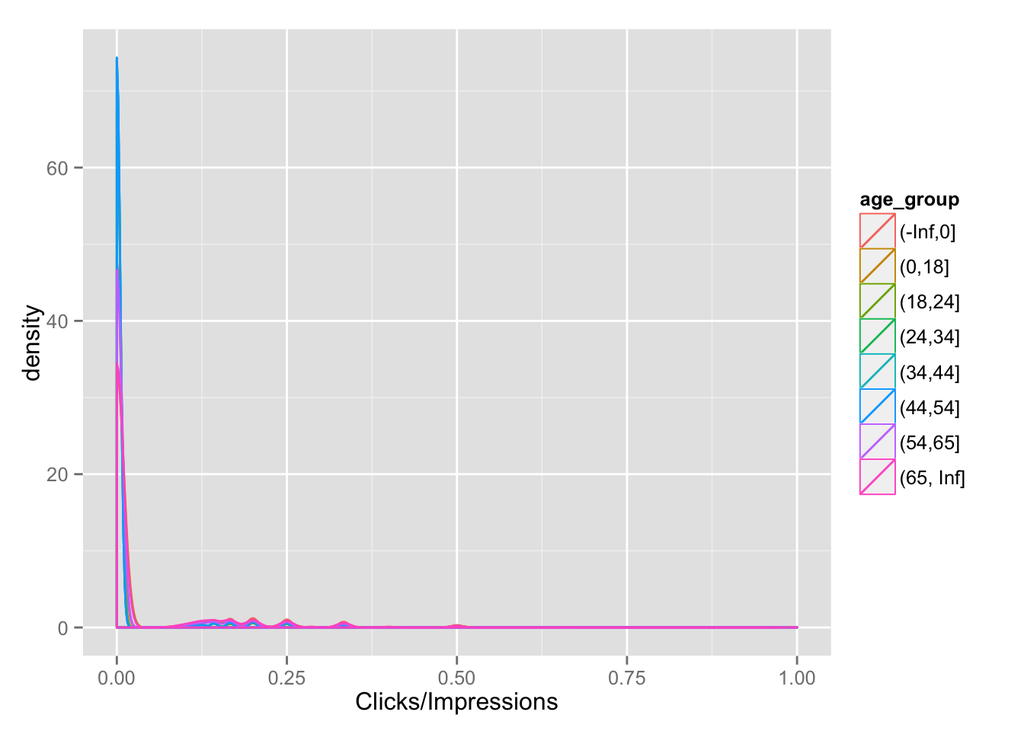

```r
ggplot(subset(data1,Impressions>0), aes(x=Clicks/Impressions, color=age_group)) + geom_density()
```

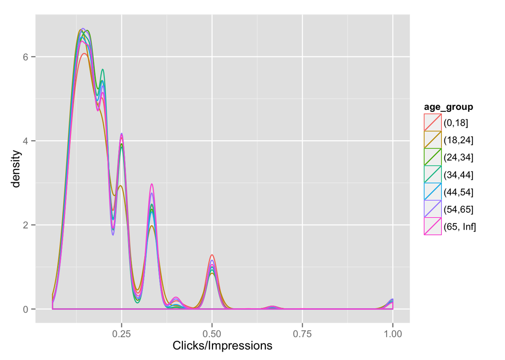

```r
ggplot(subset(data1,Clicks>0 & Age>0), aes(x=Clicks/Impressions, color=age_group)) + geom_density()
```

Let’s categorize users based on their click behavior

```r
data1$scode[data1$Impressions == 0] <- "NoImps"
data1$scode[data1$Impressions > 0] <- "Imps"
data1$scode[data1$Clicks > 0] <- "Clicks"
```

convert a column to a factor

```r
data1$scode <- factor(data1$scode)
```

look at levels

```r
clen <- function(x){c(length(x))}
etable <- summaryBy(Impressions~scode+Gender+age_group, data=data1, FUN=clen)
etable
```

```
##     scode Gender age_group Impressions.clen
## 1  Clicks      0  (-Inf,0]            17776
## 2  Clicks      0    (0,18]              846
## 3  Clicks      0   (18,24]              779
## 4  Clicks      0   (24,34]             1361
## 5  Clicks      0   (34,44]             1675
## 6  Clicks      0   (44,54]             1494
## 7  Clicks      0   (54,65]             2064
## 8  Clicks      0 (65, Inf]             2540
## 9  Clicks      1    (0,18]             1525
## 10 Clicks      1   (18,24]              890
## 11 Clicks      1   (24,34]             1509
## 12 Clicks      1   (34,44]             1917
## 13 Clicks      1   (44,54]             1645
## 14 Clicks      1   (54,65]             2407
```

[output cut: 31 more lines]

# Let’s do something serious

```r
data_cleaned <- subset(data1, Age>0, Impressions>0)
```

The we add the CTR to the columns

```r
data_cleaned <- transform(data_cleaned, CTR = Clicks/Impressions)
```

```r
# qplot(y=CTR, x=Age, data=data_cleaned, geom=c("boxplot", "jitter"))
```